#### CMSC 320

#### HW 1

#### Data types

*1) Provide a URL to the dataset.*

Dataset source: https://catalog.data.gov/dataset/most-popular-baby-names-by-sex-and-mothers-ethnic-group-new-york-city-8c742

*2) Explain why you chose this dataset.*

I found the data set to be interesting since I visit the city often and was curious. The dataset is clear and concise so I can create a plot easily. The file size also was quite reasonable and not extremely large.

*3) What are the entities in this dataset? How many are there?*

The entitites are babies born between 2011 and 2014 in NYC. There are 22,035 entities in the dataset.

*4) How many attributes are there in this dataset?*

There are 6 attributes: Year of Birth, Gender, Ethnicity, Child’s First Name, Count, Rank.

*5) What is the datatype of each attribute (categorical -ordered or unordered-, numeric -discrete or continuous-, datetime, geolocation, other)? Write a short sentence stating how you determined the type of each attribute. Do this for at least 5 attributes, if your dataset contains more than 10 attributes, choose 10 of them to describe.*

| Num | Name | Type | Description |
| --- | --- | --- | --- |
| 1 | `Year of Birth` | numeric-discrete | The year must be 2011, 2012, 2013, or 2014 |
| 2 | `Gender` | categorical-unordered | Non-numeric, must be from the (unordered) set M, F |
| 3 | `Ethnicity` | categorical-unordered | Non-numeric, must be from a finites set of (unordered) ethnicities |
| 4 | `Child's First Name` | categorical-unordered | Name is being used to build models |
| 5 | `Count` | numeric-discrete | Must be an exact whole number |
| 6 | `Rank` | numeric-discrete | Must be an exact whole number |

*6) Write R code that loads the dataset using function `read_csv`. Were you able to load the data successfully? If no, why not?*

```r
library(tidyverse)

name_tab <- read_csv("/Users/nishant/Desktop/data_science/Most_Popular_Baby_Names_by_Sex_and_Mother_s_Ethnic_Group__New_York_City.csv")
name_tab %>% slice(1:10)
```

```
## # A tibble: 10 x 6
##    `Year of Birth` Gender Ethnicity `Child's First Name` Count  Rank
##              <int> <chr>  <chr>     <chr>                <int> <int>
##  1            2011 FEMALE HISPANIC  GERALDINE               13    75
##  2            2011 FEMALE HISPANIC  GIA                     21    67
##  3            2011 FEMALE HISPANIC  GIANNA                  49    42
##  4            2011 FEMALE HISPANIC  GISELLE                 38    51
##  5            2011 FEMALE HISPANIC  GRACE                   36    53
##  6            2011 FEMALE HISPANIC  GUADALUPE               26    62
##  7            2011 FEMALE HISPANIC  HAILEY                 126     8
##  8            2011 FEMALE HISPANIC  HALEY                   14    74
##  9            2011 FEMALE HISPANIC  HANNAH                  17    71
## 10            2011 FEMALE HISPANIC  HAYLEE                  17    71
```

#### Wrangling

```r
top_5_tab <- name_tab %>%
  filter(`Year of Birth` == 2013) %>%
  select(Gender, Ethnicity, `Child's First Name`, Count) %>%
  unique() %>%
  group_by(Ethnicity="HISPANIC") %>%
  arrange(desc(Count)) %>%
  slice(1:5)
top_5_tab
```

```
## # A tibble: 5 x 4
## # Groups:   Ethnicity [1]
##   Gender Ethnicity `Child's First Name` Count
##   <chr>  <chr>     <chr>                <int>
## 1 MALE   HISPANIC  Jayden                 352
## 2 FEMALE HISPANIC  Isabella               326
## 3 MALE   HISPANIC  David                  304
## 4 MALE   HISPANIC  Jacob                  297
## 5 FEMALE HISPANIC  Sophia                 291
```

#### Plotting

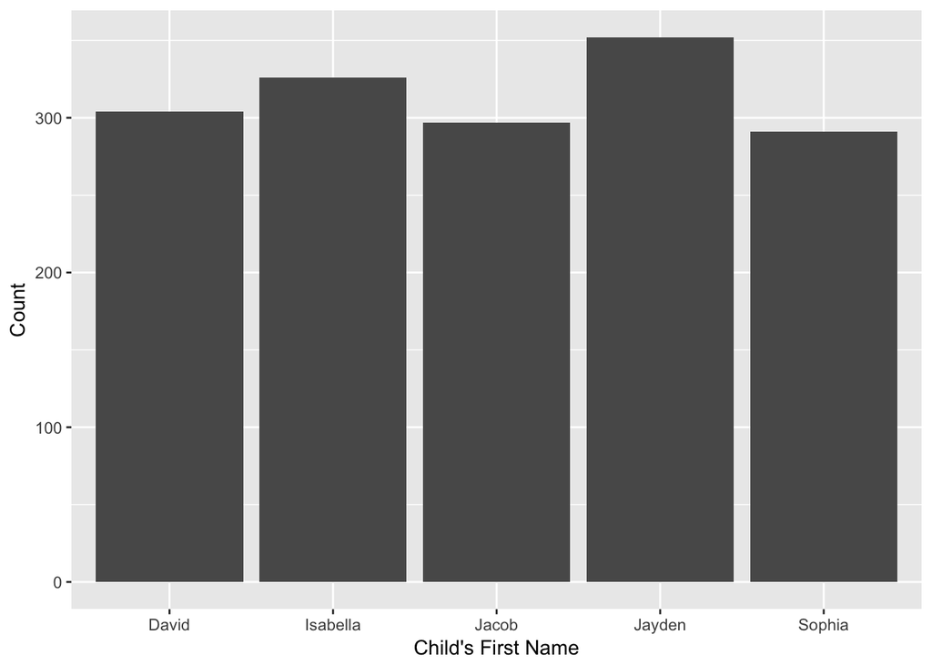

```r
top_5_tab %>%
  ggplot(aes(x=`Child's First Name`, y=Count)) + geom_bar(stat="identity")
```

```r
top_5_tab
```

```
## # A tibble: 5 x 4
## # Groups:   Ethnicity [1]
##   Gender Ethnicity `Child's First Name` Count
##   <chr>  <chr>     <chr>                <int>
## 1 MALE   HISPANIC  Jayden                 352
## 2 FEMALE HISPANIC  Isabella               326
## 3 MALE   HISPANIC  David                  304
## 4 MALE   HISPANIC  Jacob                  297
## 5 FEMALE HISPANIC  Sophia                 291
```